# R Markdown Demo

This R Markdown file contains R code you can use to complete the exercises from the Introduction to R Markdown workshop. To see the output simply click on *Knit HTML* above. This might prompt you to install and load some required packages, specifically `knitr`. Just click yes, and the a document including this narrative, the R code, and figures should pop up.

## Data

The `read.csv` function is used to read the data into R. Note that the argument provided for this function is the complete path that leads to the dataset from your current working directory (where this R Markdown file is located). Also note that this is provided as a character string, hence in quotation marks.

```r
gap_5060 <- read.csv("data/gapminder-5060.csv")
```

## Packages

We will use the `ggplot2` and `dplyr` packages to make the plots for these exercises.

- `ggplot2` for plotting: This is not the only way to make this plot, but this package has some aesthetic defaults that makes it attractive. Find out more about the package at http://ggplot2.org/.
- `dplyr` for data wrangling: This is not the only way manipulate data in R, but this package uses piping and a simple set of verbs for most common data wranling tasks which makes it attractive. See the package vignette at https://cran.rstudio.com/web/packages/dplyr/vignettes/introduction.html.

At this point you should have installed these packages using `install.packages()`.

Now we need to explicitly load the packages:

```r
library("ggplot2")
library("dplyr")
```

## Exercises

#### Task 1: Visualize life expectancy over time for Canada in the 1950s and 1960s using a line plot.

1. Filter the data for Canada only:

```r
gap_5060_CA <- gap_5060 %>%
  filter(country == "Canada")
```

2. Visaualize:

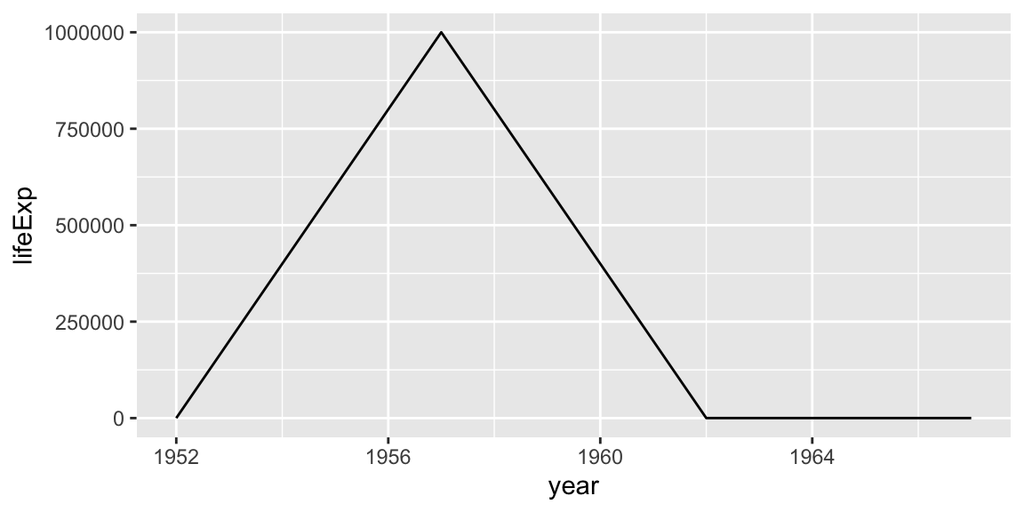

```r
ggplot(data = gap_5060_CA, aes(x = year, y = lifeExp)) +
  geom_line()
```

#### Task 2: Something is clearly wrong with this plot! Turns out there’s a data error in the data file: life expectancy for Canada in the year 1957 is coded as `999999`, it should actually be `69.96`. Make this correction.

- `mutate` for creating a new variables
- `replace` for replacing a data entry in a specific location as determined by the logical statement `(country == "Canada" & year == 1957)`

```r
gap_5060 <- gap_5060 %>%
  mutate(lifeExp = replace(lifeExp, (country == "Canada" & year == 1957), 69.96)) %>%
  as.data.frame()
```

#### Task 3: Visualize life expectancy over time for Canada again, with the corrected data.

Exact same code as before, but note that the contents of `gap_5060` are different as it has been updated in the previous task.

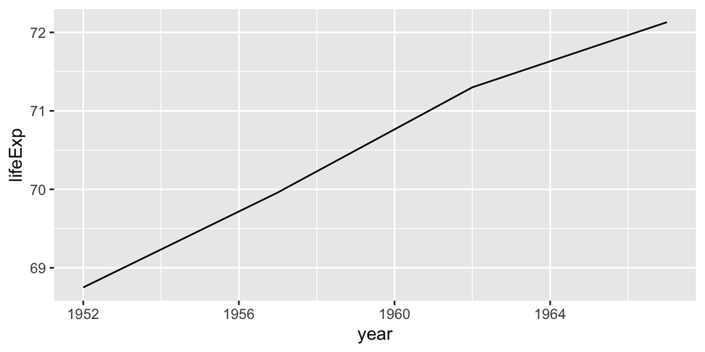

```r
gap_5060_CA <- gap_5060 %>%
  filter(country == "Canada")

ggplot(data = gap_5060_CA, aes(x = year, y = lifeExp)) +
  geom_line()
```

#### Task 3 - Stretch goal: Add lines for Mexico and United States.

- `%in%` for logical operator testing if a country’s name is in the list provided
- Same visualization code as before, only difference is the input dataset

```r
# Add your code for Mexico and the US here.
```

#### Extending your analysis with new data:

Load the new data:

```r
gap_7080 <- read.csv("data/gapminder-7080.csv")
gap_90plus <- read.csv("data/gapminder-90plus.csv")
```

Cobine data frames with `rbind` (**r**ow bind):

```r
gap <- rbind(gap_5060, gap_7080, gap_90plus)
```

1. Canada only:

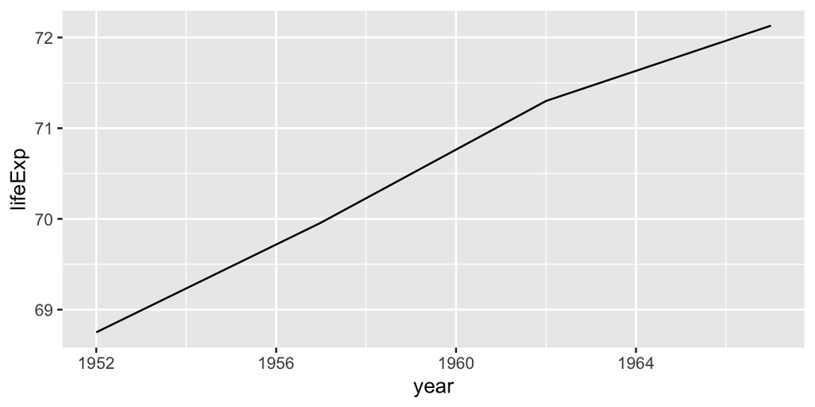

```r
gap_CA <- gap_5060 %>%
  filter(country == "Canada")

ggplot(data = gap_CA, aes(x = year, y = lifeExp)) +
  geom_line()
```

2. North America:

```r
# Add your code for Mexico and the US here.
```

## Inline code

```r
x <- 2 * 2
x
```

```
## [1] 4
```